# MATH 448 Project Progress Report II

Ulices Gonzalez

May 23rd, 2025

# Trends in Library Use Before, During, and After the COVID-19 Pandemic

## Introduction

In March of 2020 COVID-19 was declared a Pandemic Worldwide which disrupted infrastructure, business, travel, and the lifestyles of everyone. Given the way the virus is transmitted many libraries had to close their doors. The American Library Association (ALA) surveyed libraries nationwide which included public and academic libraries, in their findings the ALA reported that almost 99% of participating libraries had limited to no access to their branches. Between March of 2020 to April 2021 most libraries were closed to the public and offered alternative services such as Front Door Service and Virtual Library Catalogs. Having been hired at the time of libraries being reopened nationwide, I and other members of the public were not, and still not aware of the scale at which the Pandemic impacted the use of Library Branches. Libraries are not just used for checking out reading and visual materials but offer many resources to the public which range from computing, literacy programs, student meals, and many more necessities which many members of the public rely on. By looking at patron statistics from 2019 to 2024 it allows a better insight into the current state of library use while allowing us to understand the decline, recovery, and plateau libraries have had to face and still do and what factors have influenced this since.

## Description of Data and Variables

By using this data, we can examine trends in library usage but also the impact the pandemic had on the usage of library services overall. Specifically, by looking at the data from 2019 to understand the statistics prior to the pandemic we can get a good idea of where library usage peaked. Considering that the pandemic was officially declared in 2020 the best data to look at for the immediate impact would be 2021 as the data for 2022 would be after some safety guidelines were lifted. Lastly, to see the overall impact the pandemic has had a year after it was officially declared over the data from 2024 will be considered and compared along with that of 2019 and 2021.

## Data Processing

Due to the manner in which The Chicago Public Library data sets are provided, many predictors are separated into their own tables which require some additional work in order to combine them with other statistics collected in a give year. For example Item Circulation, Holds, and Computer Sessions are reported in their own sets so in order to look at their influence on Visitation. This took some work and adjustment but was a feasible task due to the size of each given data set being fixed. Some pieces of data were excluded from the final data set particularly online items, holds placed by patrons outside of a branch, and automatic renewals as these padded the statistics in a manner that treated them as their own library branches.

When processing the data from data.gov into r I began by reading each file and making the process of this easier by creating a function that could handle this faster. Once all the files have been read and I took a look at the data I realize that it would be tedious for each predictor to be output as their own data set. From here I began the process of compiling all the data for a given year into a table which led to the creation of the process_year_data function that would compile all the statistics into a single table with each predictor as its own column. This gave a really good output as the data can now be called however the caveat to this is that each library has a row every month of the year meaning that all 80 libraries now had 12 rows leading to each table for a given year having 960 different rows to examine. This was kept as this allows for an examination of extremes and other relevant data but in order to get a better overview the aggregate_year_data function was created to compile the data further by calculating the sum of all the statistics for a given library. With this now being completed it allowed for the data to finally be analyzed with greater ease and cleaner statistics.

## Descriptive Analysis

Lastly Computer Sessions in 2019 had a clear relationship with visitation, with it being extremely consistent with one another with very few changes. In 2021, however, it is expected that this would become more varied throughout the pandemic along with it going down in scale. Of the three years being examined though, 2024 seems to show the largest change in variance as there is more inconsistency in the relationship between sessions and visitation. It also shows some signs of growth but is closer to that of what was reported in 2021. (Obvious outliers are not being considered in this analysis)

## Simple Linear Regression Model

Simple linear regression models were used to analyze the individual relationships between library visitation (Visitation) and each of the predictor variables: Circulation, Holds, and Computer Sessions (Sessions) across 2019, 2021, and 2024. For each year and each predictor, a separate linear model was fitted to observe the direction and strength of their relationship with Visitation. Specifically, the relationship between Circulation and Visitation appears positive and statistically significant across all three years. However it’s much more clear after applying the linear regression that there is a sharp fall off in visitation which shows the effect of low circulation on visitation numbers. Looking at the results from the regression for 2024 there is an increase both in circulation and visitation with the relationship becoming much more positive.

## Multiple Linear Regression Model

Similarly to the simple linear regression multiple linear regression models are applied to the data amongst all three years to take into account their collective relationships in influencing visitation. However compared to the simple linear regressions there is a much more obvious shift in variability in the between the data set and its regression models. The high R-squared values for all three years explain a substantial portion of the variance in library visitation while the rest can be associated to the inconsistency amongst each of the predictor variables data entries. The results are very much the same as the simple linear regression models but it is much clearer that the holds amongst all three years have the least influence on visitation as opposed to circulation and computer sessions. This also reiterates the fact that both circulation and computer sessions have a larger impact on visitation.

## Polynomial Regression Model

Lastly, polynomial regressions were used in order to take into account that there may be nonlinear relationships present amongst the data set. This was partly done due to the fact that the data set is looking at data from 12 months out of the years of 2019, 2021, and 2024. Using the polynomial regression allows to observe any kinds of nonlinear trends amongst these time windows as there’s the potential of them either positively and negatively affecting visitation due to library closures and specifically in the case of this project the covid-19 pandemic. For the regression squared terms were used after experimenting with different combinations of exponential values with the squared iteration being the most consistent amongst them all.

The higher R-squared values for the polynomial models compared to the linear models for each year suggest that incorporating non-linear terms improves the model’s ability to explain the variance in Visitation. The statistical significance of the linear and quadratic terms varies across predictors and years, indicating that the nature of the relationship may differ for each factor which could be associated with the pandemics effect on library services. The results of the polynomial regression were very similar to that of the multiple linear regressions albeit show more stable predictions if we look at the regression line on the plots. The main takeaway however is the fact that the relationships are shown to be slightly more consistent than the rest of the models.

## Model Comparisons

Due to the way that this data set is set up it was difficult to choose which regression methods to apply given that I’m looking at 3 years worth of data and working with a limited amount of predictor variables that influence visitation. While there are a lot of options in terms of the methods that we can apply the most suitable the linear regressions along with the polynomial regressions because of all the data entries being numerical and with them being somewhat of a small data set these regression methods were simple enough to apply to them. Of all the three the best performing one in my opinion had to be the polynomial regression because it was able to take into account not just the fact that there’s the potential for a nonlinear relationship amongst each of the predictors and visitation but also the fact that it showed more stability when it came to the predictions created with the regression. This made the data much easier to interpret and analyze compared to the two linear regression types that were performed. The simple in your regression while it was useful to look at the relationship of visitation with each predictor it didn’t perform as well as I thought given the fact that there are relationships between each of the predictors and not just with the visitation itself. This can be seen in the graphs that were plotted as strictly positive relationships and this isn’t realistic given the way that Trends in library use are. Similarly to the polynomial the multiple regression method was effective in considering the changes in the relationships amongst the visitation and the predictors showed accurate predictions when compared to the original data set with enough information being provided to explain the variability. However the main issue I saw when performing the multiple linear regression is the fact that there is a lot more variability compared to that of the polynomial making it more difficult to analyze. Overall, while all three of the methods I applied were useful in analyzing the data, the best performing and most suitable choice for the data set was the polynomial regression especially because it fit the data the best amongst the three.

## Appendix

### I. Data Read

```r
data_dir <- "LibraryData/"

load_year_data <- function(year)
{
  visitors_file <- paste0(data_dir, year, "Visitors.csv")
  circ_file <- paste0(data_dir, year, "Circ.csv")
  holds_file <- paste0(data_dir, year, "Holds.csv")
  computer_file <- paste0(data_dir, year, "Computer.csv")


  visitors <- read_csv(visitors_file)
  circ <- read_csv(circ_file)
  holds <- read_csv(holds_file)
  computer <- read_csv(computer_file)

  return(list(visitors = visitors, circ = circ, holds = holds, computer = computer))
}

data_2019 <- load_year_data(2019)
data_2021 <- load_year_data(2021)
data_2024 <- load_year_data(2024)
```

### II. Data Preparation

#### II.I. Data Processing

```r
process_year_data <- function(year, data_list)
{
  visitors <- data_list$visitors
  circ <- data_list$circ
  holds <- data_list$holds
  holds <- holds %>% mutate(across(c(-LOCATION), as.numeric))
  computer <- data_list$computer

  visitors_long <- visitors %>% pivot_longer(cols = -LOCATION, names_to = "Month", values_to = "Visitation")
  circ_long <- circ %>% pivot_longer(cols = -LOCATION, names_to = "Month", values_to = "Circulation")
  holds_long <- holds %>% pivot_longer(cols = -LOCATION, names_to = "Month", values_to = "Holds")
  computer_long <- computer %>% pivot_longer(cols = -LOCATION, names_to = "Month", values_to = "Sessions")

  month_order <- c("JANUARY", "FEBRUARY", "MARCH", "APRIL", "MAY", "JUNE", "JULY", "AUGUST", "SEPTEMBER", "OCTOBER", "NOVEMBER", "DECEMBER")

  visitors_long$Month <- factor(visitors_long$Month, levels = month_order)
  circ_long$Month <- factor(circ_long$Month, levels = month_order)
  holds_long$Month <- factor(holds_long$Month, levels = month_order)
  computer_long$Month <- factor(computer_long$Month, levels = month_order)

  visitors_long$LOCATION <- str_trim(visitors_long$LOCATION)
  circ_long$LOCATION <- str_trim(circ_long$LOCATION)
  holds_long$LOCATION <- str_trim(holds_long$LOCATION)
  computer_long$LOCATION <- str_trim(computer_long$LOCATION)

  merged_year_data <- visitors_long %>%
  left_join(circ_long, by = c("LOCATION", "Month")) %>%
  left_join(holds_long, by = c("LOCATION", "Month")) %>%
  left_join(computer_long, by = c("LOCATION", "Month"))

  merged_year_data <- merged_year_data %>%
  mutate(Year = year) %>%
  select(LOCATION, Visitation, Circulation, Holds, Sessions, Month, Year)

  return(merged_year_data)
}

processed_2019 <- process_year_data(2019, data_2019)
processed_2021 <- process_year_data(2021, data_2021)
processed_2024 <- process_year_data(2024, data_2024)
```

#### II.II. Data Aggregation

```r
aggregate_year_data <- function(year, data_list)
{
  visitors <- data_list$visitors
  circ <- data_list$circ
  holds <- data_list$holds
  computer <- data_list$computer

  visitors_yearly <- visitors %>%
  mutate(across(c(-LOCATION), as.numeric)) %>%
  mutate(LOCATION = str_trim(LOCATION)) %>%
  group_by(LOCATION) %>%
  summarise(Visitation = sum(across(where(is.numeric)), na.rm = TRUE))

  circ_yearly <- circ %>%
  mutate(across(c(-LOCATION), as.numeric)) %>%
  mutate(LOCATION = str_trim(LOCATION)) %>%
  group_by(LOCATION) %>%
  summarise(Circulation = sum(across(where(is.numeric)), na.rm = TRUE))

  holds_yearly <- holds %>%
  mutate(across(c(-LOCATION), as.numeric)) %>%
  mutate(LOCATION = str_trim(LOCATION)) %>%
  group_by(LOCATION) %>%
  summarise(Holds = sum(across(where(is.numeric)), na.rm = TRUE))

  computer_yearly <- computer %>%
  mutate(across(c(-LOCATION), as.numeric)) %>%
  mutate(LOCATION = str_trim(LOCATION)) %>%
  group_by(LOCATION) %>%
  summarise(Sessions = sum(across(where(is.numeric)), na.rm = TRUE))

  merged_year_data <- visitors_yearly %>%
  left_join(circ_yearly, by = "LOCATION") %>%
  left_join(holds_yearly, by = "LOCATION") %>%
  left_join(computer_yearly, by = "LOCATION")

  merged_year_data <- merged_year_data %>%
  mutate(Year = year) %>%
  select(LOCATION, Visitation, Circulation, Holds, Sessions, Year)

  return(merged_year_data)
}

aggregated_2019 <- aggregate_year_data(2019, data_2019)
aggregated_2021 <- aggregate_year_data(2021, data_2021)
aggregated_2024 <- aggregate_year_data(2024, data_2024)
```

### III. Descriptive analysis

#### III.II. Data Summary

```r
summary(aggregated_2019 %>% select(-LOCATION, -Year))
```

```
##    Visitation       Circulation         Holds           Sessions
##  Min.   :      0   Min.   :  1250   Min.   :  28.0   Min.   :     0
##  1st Qu.:  50799   1st Qu.: 17074   1st Qu.: 509.5   1st Qu.: 10465
##  Median :  74725   Median : 37880   Median : 892.0   Median : 14292
##  Mean   : 100495   Mean   : 59089   Mean   :1216.2   Mean   : 19430
##  3rd Qu.: 104360   3rd Qu.: 67621   3rd Qu.:1539.5   3rd Qu.: 21769
##  Max.   :1405964   Max.   :581151   Max.   :4807.0   Max.   :209583
##                                     NA's   :1
```

```r
summary(aggregated_2021 %>% select(-LOCATION, -Year))
```

```
##    Visitation      Circulation         Holds           Sessions
##  Min.   :     0   Min.   :     0   Min.   :   0.0   Min.   :    0
##  1st Qu.: 16756   1st Qu.:  7287   1st Qu.: 285.0   1st Qu.: 4898
##  Median : 33300   Median : 20184   Median : 600.0   Median : 6663
##  Mean   : 44552   Mean   : 37138   Mean   : 855.9   Mean   : 7385
##  3rd Qu.: 53595   3rd Qu.: 55453   3rd Qu.:1209.0   3rd Qu.: 8963
##  Max.   :543951   Max.   :281183   Max.   :3476.0   Max.   :28566
##                   NA's   :3        NA's   :3        NA's   :3
```

```r
summary(aggregated_2024 %>% select(-LOCATION, -Year))
```

```
##    Visitation      Circulation         Holds            Sessions
##  Min.   :     0   Min.   :     0   Min.   :    0.0   Min.   :    0
##  1st Qu.: 37640   1st Qu.:  8863   1st Qu.:  366.0   1st Qu.: 7408
##  Median : 49725   Median : 20606   Median :  849.5   Median :10630
##  Mean   : 69333   Mean   : 38881   Mean   : 1234.5   Mean   :11432
##  3rd Qu.: 76192   3rd Qu.: 56139   3rd Qu.: 1612.8   3rd Qu.:14220
##  Max.   :653728   Max.   :311851   Max.   :15230.0   Max.   :42065
##                   NA's   :3                          NA's   :3
```

#### III.III. Data Visualization

##### III.III.I. Scatter Plots

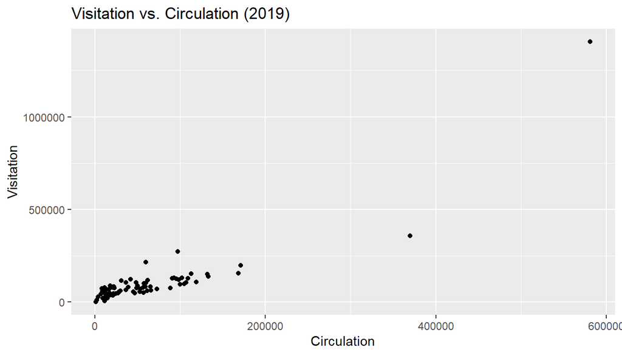

```r
options(scipen = 999)

ggplot(aggregated_2019, aes(x= Circulation, y = Visitation)) + geom_point() + labs(title = "Visitation vs. Circulation (2019)", x = "Circulation", y = "Visitation")
```

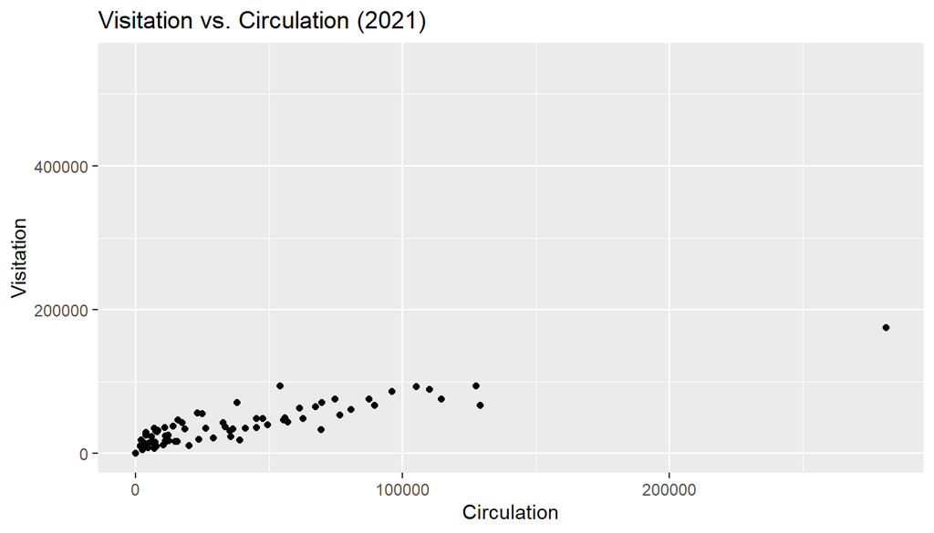

```r
ggplot(aggregated_2021, aes(x= Circulation, y = Visitation)) + geom_point() + labs(title = "Visitation vs. Circulation (2021)", x = "Circulation", y = "Visitation")
```

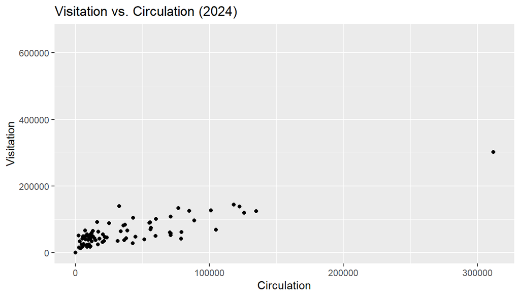

```r
ggplot(aggregated_2024, aes(x= Circulation, y = Visitation)) + geom_point() + labs(title = "Visitation vs. Circulation (2024)", x = "Circulation", y = "Visitation")
```

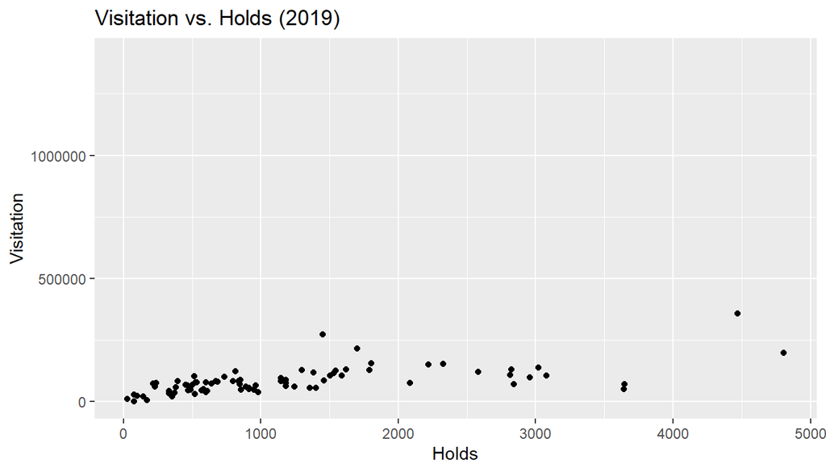

```r
ggplot(aggregated_2019, aes(x= Holds, y = Visitation)) + geom_point() + labs(title = "Visitation vs. Holds (2019)", x = "Holds", y = "Visitation")
```

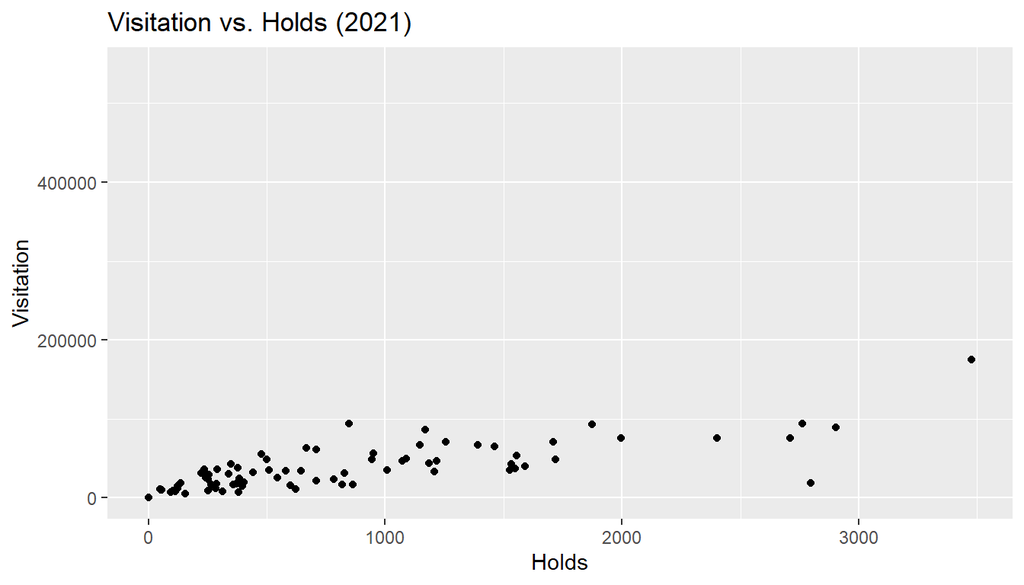

```r
ggplot(aggregated_2021, aes(x= Holds, y = Visitation)) + geom_point() + labs(title = "Visitation vs. Holds (2021)", x = "Holds", y = "Visitation")
```

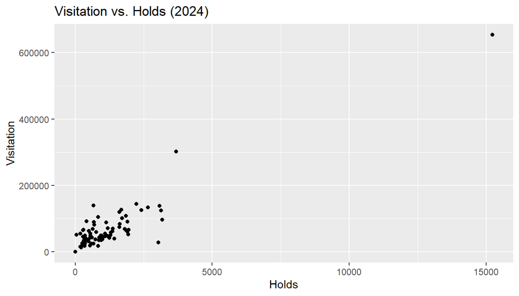

```r
ggplot(aggregated_2024, aes(x= Holds, y = Visitation)) + geom_point() + labs(title = "Visitation vs. Holds (2024)", x = "Holds", y = "Visitation")
```

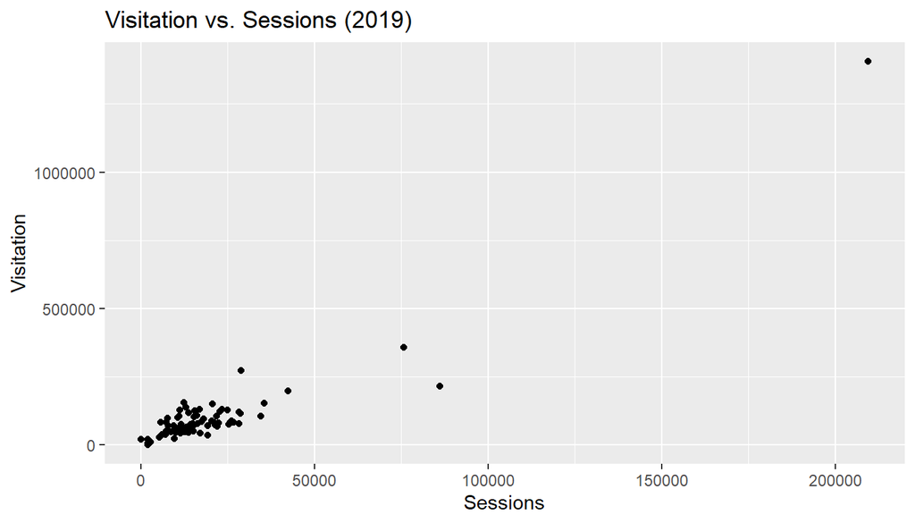

```r
ggplot(aggregated_2019, aes(x= Sessions, y = Visitation)) + geom_point() + labs(title = "Visitation vs. Sessions (2019)", x = "Sessions", y = "Visitation")
```

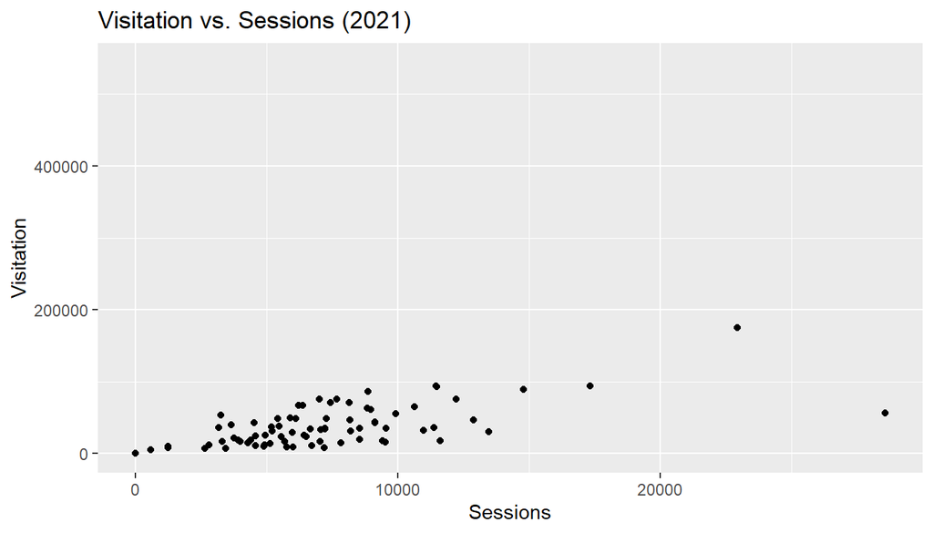

```r
ggplot(aggregated_2021, aes(x= Sessions, y = Visitation)) + geom_point() + labs(title = "Visitation vs. Sessions (2021)", x = "Sessions", y = "Visitation")
```

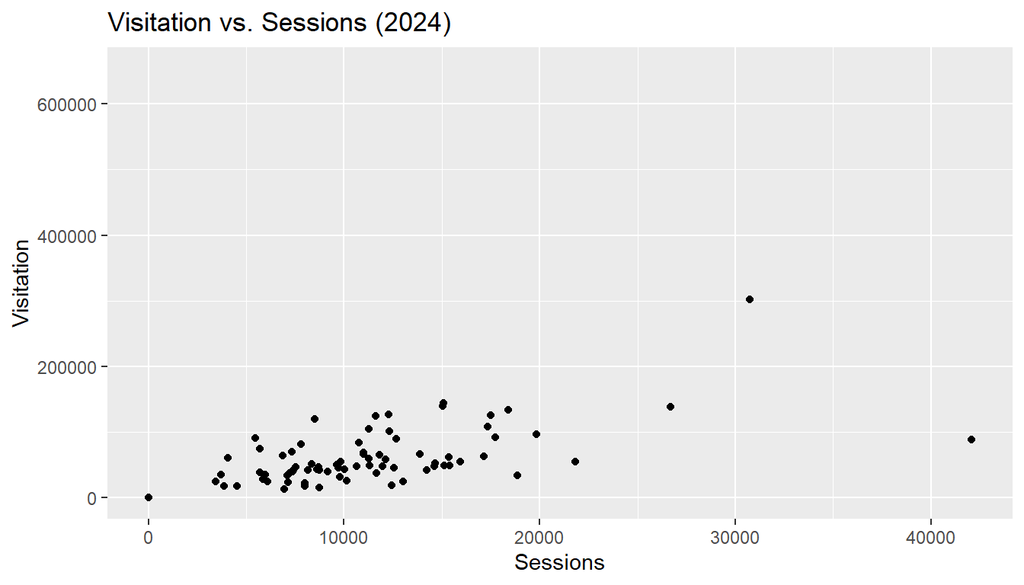

```r
ggplot(aggregated_2024, aes(x= Sessions, y = Visitation)) + geom_point() + labs(title = "Visitation vs. Sessions (2024)", x = "Sessions", y = "Visitation")
```

##### III.III.II. Bar Graphs

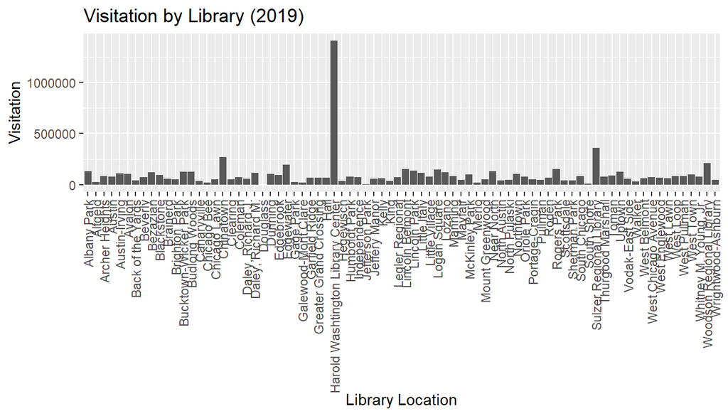

```r
ggplot(aggregated_2019, aes(x = LOCATION, y = Visitation)) + geom_bar(stat = "identity") + labs(title = "Visitation by Library (2019)", x = "Library Location", y = "Visitation") +
theme(axis.text.x = element_text(angle = 90, hjust = 1, vjust = 0.5))
```

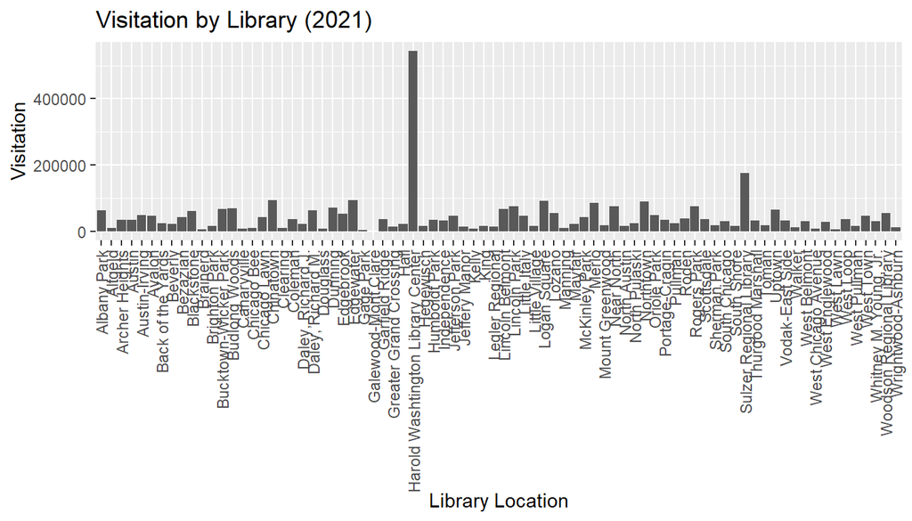

```r
ggplot(aggregated_2021, aes(x = LOCATION, y = Visitation)) + geom_bar(stat = "identity") + labs(title = "Visitation by Library (2021)", x = "Library Location", y = "Visitation") +
theme(axis.text.x = element_text(angle = 90, hjust = 1, vjust = 0.5))
```

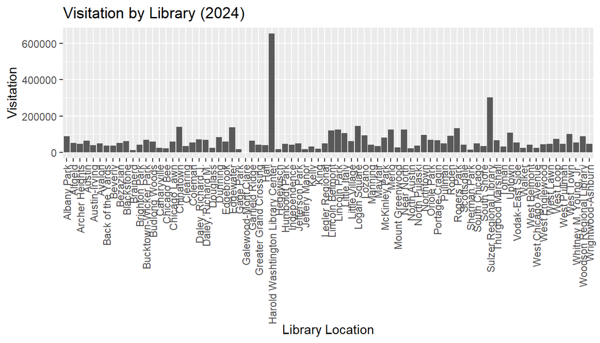

```r
ggplot(aggregated_2024, aes(x = LOCATION, y = Visitation)) + geom_bar(stat = "identity") + labs(title = "Visitation by Library (2024)", x = "Library Location", y = "Visitation") +
theme(axis.text.x = element_text(angle = 90, hjust = 1, vjust = 0.5))
```

### IV. Regression Methods Applied

#### IV.I. Simple Linear Regression

```r
sLm2019Circ <- lm(Visitation ~ Circulation, data = aggregated_2019)
sLm2019Holds <- lm(Visitation ~ Holds, data = aggregated_2019)
sLm2019Sess <- lm(Visitation ~ Sessions, data = aggregated_2019)

sLm2021Circ <- lm(Visitation ~ Circulation, data = aggregated_2021)
sLm2021Holds <- lm(Visitation ~ Holds, data = aggregated_2021)
sLm2021Sess <- lm(Visitation ~ Sessions, data = aggregated_2021)

sLm2024Circ <- lm(Visitation ~ Circulation, data = aggregated_2024)
sLm2024Holds <- lm(Visitation ~ Holds, data = aggregated_2024)
sLm2024Sess <- lm(Visitation ~ Sessions, data = aggregated_2024)
```

##### IV.I.I. 2019

```r
options(scipen = 999)

summary(sLm2019Circ)
```

```
##
## Call:
## lm(formula = Visitation ~ Circulation, data = aggregated_2019)
##
## Residuals:
##     Min      1Q  Median      3Q     Max
## -287085  -32546    5577   38380  388559
##
## Coefficients:
##               Estimate Std. Error t value            Pr(>|t|)
## (Intercept) -3285.3969 10170.7970  -0.323               0.748
## Circulation     1.7563     0.1028  17.081 <0.0000000000000002 ***
## ---
## Signif. codes:  0 '***' 0.001 '**' 0.01 '*' 0.05 '.' 0.1 ' ' 1
##
## Residual standard error: 72960 on 78 degrees of freedom
## Multiple R-squared:  0.7891, Adjusted R-squared:  0.7864
## F-statistic: 291.8 on 1 and 78 DF,  p-value: < 0.00000000000000022
```

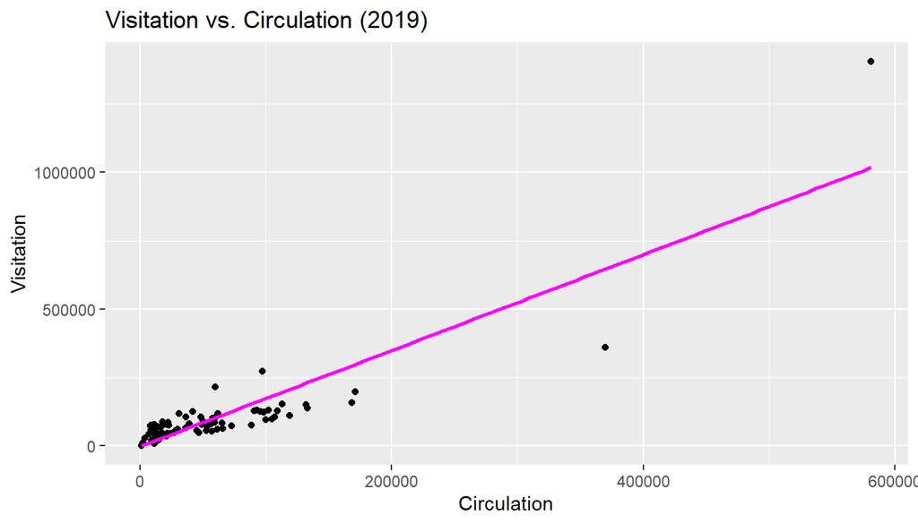

```r
ggplot(aggregated_2019, aes(x = Circulation, y = Visitation)) + geom_point() + geom_smooth(method = "lm", formula = y ~ x, se = FALSE, color = "magenta") + labs(title = "Visitation vs. Circulation (2019)", x = "Circulation", y = "Visitation")
```

```r
summary(sLm2019Holds)
```

```
##
## Call:
## lm(formula = Visitation ~ Holds, data = aggregated_2019)
##
## Residuals:
##     Min      1Q  Median      3Q     Max
## -115603  -23064   -6431   17409  179526
##
## Coefficients:
##              Estimate Std. Error t value       Pr(>|t|)
## (Intercept) 42436.324   7569.801   5.606 0.000000309516 ***
## Holds          34.150      4.756   7.181 0.000000000377 ***
## ---
## Signif. codes:  0 '***' 0.001 '**' 0.01 '*' 0.05 '.' 0.1 ' ' 1
##
## Residual standard error: 43410 on 77 degrees of freedom
##   (1 observation deleted due to missingness)
## Multiple R-squared:  0.4011, Adjusted R-squared:  0.3933
## F-statistic: 51.57 on 1 and 77 DF,  p-value: 0.000000000377
```

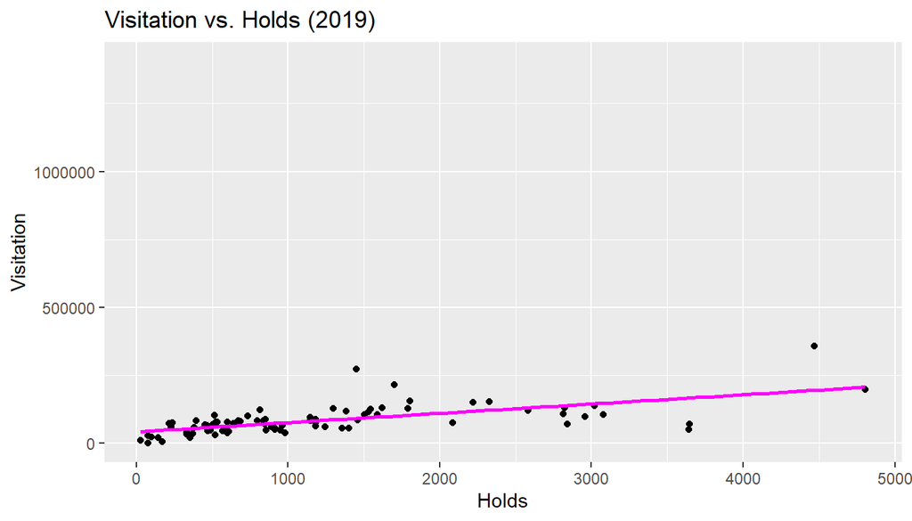

```r
ggplot(aggregated_2019, aes(x = Holds, y = Visitation)) + geom_point() + geom_smooth(method = "lm", formula = y ~ x, se = FALSE, color = "magenta") + labs(title = "Visitation vs. Holds (2019)", x = "Holds", y = "Visitation")
```

```r
summary(sLm2019Sess)
```

```
##
## Call:
## lm(formula = Visitation ~ Sessions, data = aggregated_2019)
##
## Residuals:
##     Min      1Q  Median      3Q     Max
## -277793  -25312    1448   22043  189819
##
## Coefficients:
##                Estimate  Std. Error t value            Pr(>|t|)
## (Intercept) -13504.3430   7746.8944  -1.743              0.0852 .
## Sessions         5.8671      0.2441  24.035 <0.0000000000000002 ***
## ---
## Signif. codes:  0 '***' 0.001 '**' 0.01 '*' 0.05 '.' 0.1 ' ' 1
##
## Residual standard error: 54790 on 78 degrees of freedom
## Multiple R-squared:  0.881,  Adjusted R-squared:  0.8795
## F-statistic: 577.7 on 1 and 78 DF,  p-value: < 0.00000000000000022
```

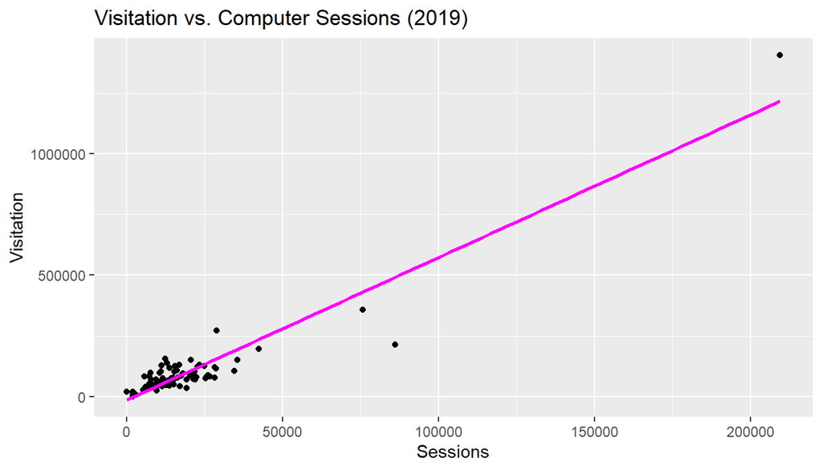

```r
ggplot(aggregated_2019, aes(x = Sessions, y = Visitation)) + geom_point() + geom_smooth(method = "lm", formula = y ~ x, se = FALSE, color = "magenta") + labs(title = "Visitation vs. Computer Sessions (2019)", x = "Sessions", y = "Visitation")
```

##### IV.I.II. 2021

```r
options(scipen = 999)

summary(sLm2021Circ)
```

```
##
## Call:
## lm(formula = Visitation ~ Circulation, data = aggregated_2021)
##
## Residuals:
##    Min     1Q Median     3Q    Max
## -25970  -8605  -3176   7713  45393
##
## Coefficients:
##                Estimate  Std. Error t value             Pr(>|t|)
## (Intercept) 15872.93425  1905.69037   8.329     0.00000000000282 ***
## Circulation     0.59825     0.03328  17.977 < 0.0000000000000002 ***
## ---
## Signif. codes:  0 '***' 0.001 '**' 0.01 '*' 0.05 '.' 0.1 ' ' 1
##
## Residual standard error: 12730 on 75 degrees of freedom
##   (3 observations deleted due to missingness)
## Multiple R-squared:  0.8116, Adjusted R-squared:  0.8091
## F-statistic: 323.2 on 1 and 75 DF,  p-value: < 0.00000000000000022
```

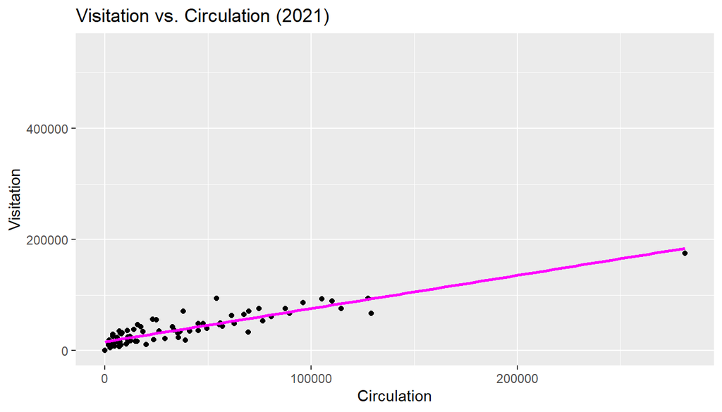

```r
ggplot(aggregated_2021, aes(x = Circulation, y = Visitation)) + geom_point() + geom_smooth(method = "lm", formula = y ~ x, se = FALSE, color = "magenta") + labs(title = "Visitation vs. Circulation (2021)", x = "Circulation", y = "Visitation")
```

```r
summary(sLm2021Holds)
```

```
##
## Call:
## lm(formula = Visitation ~ Holds, data = aggregated_2021)
##
## Residuals:
##    Min     1Q Median     3Q    Max
## -75546  -9846  -4150   8077  62009
##
## Coefficients:
##              Estimate Std. Error t value             Pr(>|t|)
## (Intercept) 13501.987   3214.939    4.20 0.000072768215060234 ***
## Holds          28.730      2.791   10.29 0.000000000000000538 ***
## ---
## Signif. codes:  0 '***' 0.001 '**' 0.01 '*' 0.05 '.' 0.1 ' ' 1
##
## Residual standard error: 18880 on 75 degrees of freedom
##   (3 observations deleted due to missingness)
## Multiple R-squared:  0.5855, Adjusted R-squared:   0.58
## F-statistic:   106 on 1 and 75 DF,  p-value: 0.000000000000000538
```

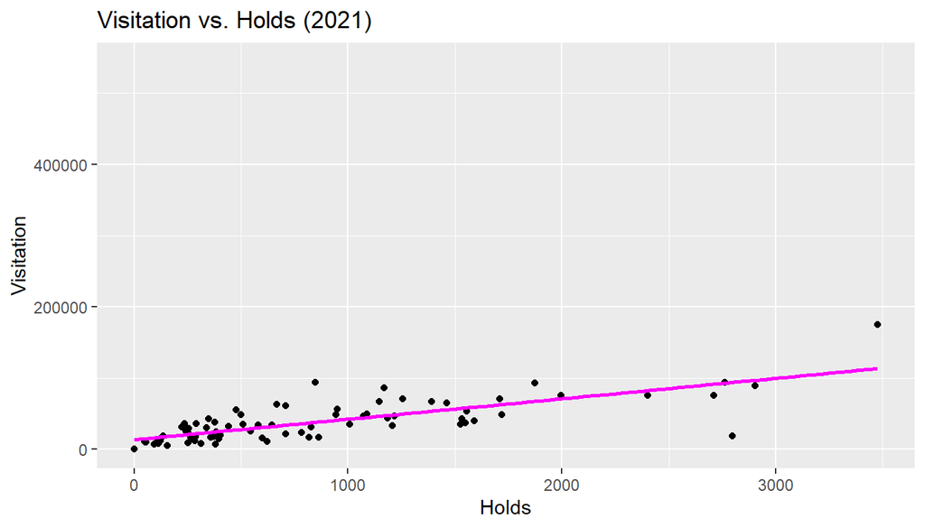

```r
ggplot(aggregated_2021, aes(x = Holds, y = Visitation)) + geom_point() + geom_smooth(method = "lm", formula = y ~ x, se = FALSE, color = "magenta") + labs(title = "Visitation vs. Holds (2021)", x = "Holds", y = "Visitation")
```

```r
summary(sLm2021Sess)
```

```
##
## Call:
## lm(formula = Visitation ~ Sessions, data = aggregated_2021)
##
## Residuals:
##    Min     1Q Median     3Q    Max
## -69698 -14273  -3451  15695  72966
##
## Coefficients:
##              Estimate Std. Error t value       Pr(>|t|)
## (Intercept) 7551.2721  5047.4092   1.496          0.139
## Sessions       4.1355     0.5865   7.051 0.000000000745 ***
## ---
## Signif. codes:  0 '***' 0.001 '**' 0.01 '*' 0.05 '.' 0.1 ' ' 1
##
## Residual standard error: 22740 on 75 degrees of freedom
##   (3 observations deleted due to missingness)
## Multiple R-squared:  0.3986, Adjusted R-squared:  0.3906
## F-statistic: 49.72 on 1 and 75 DF,  p-value: 0.0000000007445
```

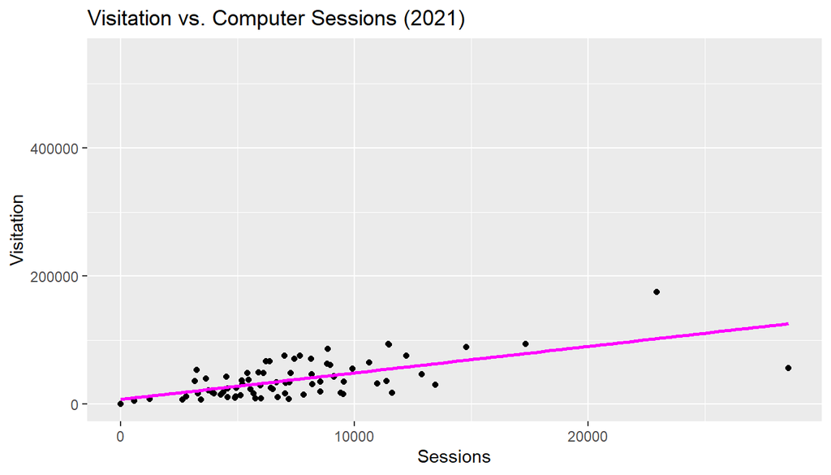

```r
ggplot(aggregated_2021, aes(x = Sessions, y = Visitation)) + geom_point() + geom_smooth(method = "lm", formula = y ~ x, se = FALSE, color = "magenta") + labs(title = "Visitation vs. Computer Sessions (2021)", x = "Sessions", y = "Visitation")
```

##### IV.I.III. 2024

```r
options(scipen = 999)

summary(sLm2024Circ)
```

```
##
## Call:
## lm(formula = Visitation ~ Circulation, data = aggregated_2024)
##
## Residuals:
##    Min     1Q Median     3Q    Max
## -52122 -17749   -183  15198  82884
##
## Coefficients:
##                Estimate  Std. Error t value             Pr(>|t|)
## (Intercept) 30672.75484  3495.60742   8.775      0.0000000000004 ***
## Circulation     0.79881     0.05794  13.787 < 0.0000000000000002 ***
## ---
## Signif. codes:  0 '***' 0.001 '**' 0.01 '*' 0.05 '.' 0.1 ' ' 1
##
## Residual standard error: 23460 on 75 degrees of freedom
##   (3 observations deleted due to missingness)
## Multiple R-squared:  0.7171, Adjusted R-squared:  0.7133
## F-statistic: 190.1 on 1 and 75 DF,  p-value: < 0.00000000000000022
```

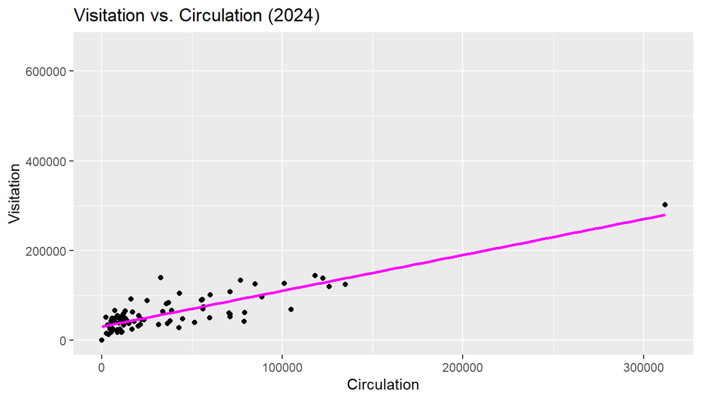

```r
ggplot(aggregated_2024, aes(x = Circulation, y = Visitation)) + geom_point() + geom_smooth(method = "lm", formula = y ~ x, se = FALSE, color = "magenta") + labs(title = "Visitation vs. Circulation (2024)", x = "Circulation", y = "Visitation")
```

```r
summary(sLm2024Holds)
```

```
##
## Call:
## lm(formula = Visitation ~ Holds, data = aggregated_2024)
##
## Residuals:
##     Min      1Q  Median      3Q     Max
## -114055  -17904   -5670   14242  133678
##
## Coefficients:
##              Estimate Std. Error t value             Pr(>|t|)
## (Intercept) 19393.560   4341.152   4.467            0.0000264 ***
## Holds          40.453      2.008  20.149 < 0.0000000000000002 ***
## ---
## Signif. codes:  0 '***' 0.001 '**' 0.01 '*' 0.05 '.' 0.1 ' ' 1
##
## Residual standard error: 31880 on 78 degrees of freedom
## Multiple R-squared:  0.8388, Adjusted R-squared:  0.8368
## F-statistic:   406 on 1 and 78 DF,  p-value: < 0.00000000000000022
```

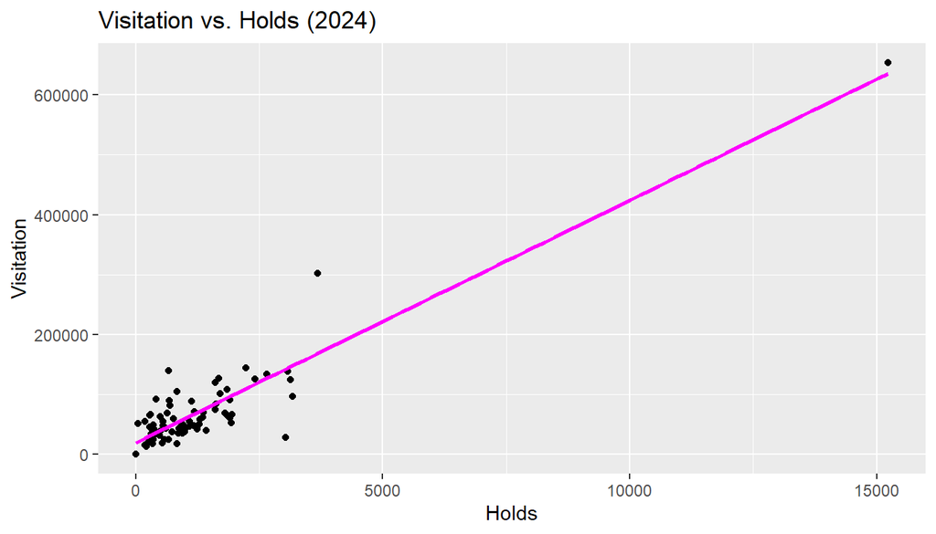

```r
ggplot(aggregated_2024, aes(x = Holds, y = Visitation)) + geom_point() + geom_smooth(method = "lm", formula = y ~ x, se = FALSE, color = "magenta") + labs(title = "Visitation vs. Holds (2024)", x = "Holds", y = "Visitation")
```

```r
summary(sLm2024Sess)
```

```
##
## Call:
## lm(formula = Visitation ~ Sessions, data = aggregated_2024)
##
## Residuals:
##    Min     1Q Median     3Q    Max
## -97200 -21011  -5986  15267 162573
##
## Coefficients:
##               Estimate Std. Error t value     Pr(>|t|)
## (Intercept) 15544.5158  8574.4340   1.813       0.0738 .
## Sessions        4.0401     0.6587   6.133 0.0000000371 ***
## ---
## Signif. codes:  0 '***' 0.001 '**' 0.01 '*' 0.05 '.' 0.1 ' ' 1
##
## Residual standard error: 35990 on 75 degrees of freedom
##   (3 observations deleted due to missingness)
## Multiple R-squared:  0.334,  Adjusted R-squared:  0.3252
## F-statistic: 37.62 on 1 and 75 DF,  p-value: 0.00000003713
```

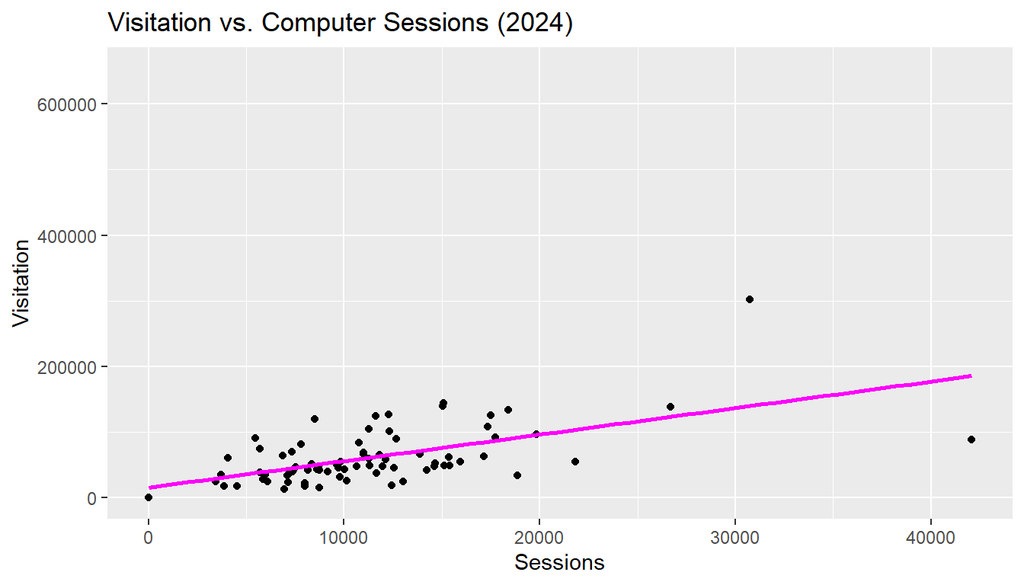

```r
ggplot(aggregated_2024, aes(x = Sessions, y = Visitation)) + geom_point() + geom_smooth(method = "lm", formula = y ~ x, se = FALSE, color = "magenta") + labs(title = "Visitation vs. Computer Sessions (2024)", x = "Sessions", y = "Visitation")
```

#### IV.II. Multiple Linear Regression

```r
mLm2019 <- lm(Visitation ~ Circulation + Holds + Sessions, data = aggregated_2019)
mLm2021 <- lm(Visitation ~ Circulation + Holds + Sessions, data = aggregated_2021)
mLm2024 <- lm(Visitation ~ Circulation + Holds + Sessions, data = aggregated_2024)
```

##### IV.II.I. 2019

```r
summary(mLm2019)
```

```
##
## Call:
## lm(formula = Visitation ~ Circulation + Holds + Sessions, data = aggregated_2019)
##
## Residuals:
##    Min     1Q Median     3Q    Max
## -39005 -10563  -3648   8522 135512
##
## Coefficients:
##                Estimate  Std. Error t value           Pr(>|t|)
## (Intercept) 19439.29378  4463.93455   4.355 0.0000416123095094 ***
## Circulation     0.65147     0.07889   8.258 0.0000000000038549 ***
## Holds          -2.66614     3.89539  -0.684              0.496
## Sessions        1.97279     0.21638   9.117 0.0000000000000892 ***
## ---
## Signif. codes:  0 '***' 0.001 '**' 0.01 '*' 0.05 '.' 0.1 ' ' 1
##
## Residual standard error: 22000 on 75 degrees of freedom
##   (1 observation deleted due to missingness)
## Multiple R-squared:  0.8501, Adjusted R-squared:  0.8441
## F-statistic: 141.8 on 3 and 75 DF,  p-value: < 0.00000000000000022
```

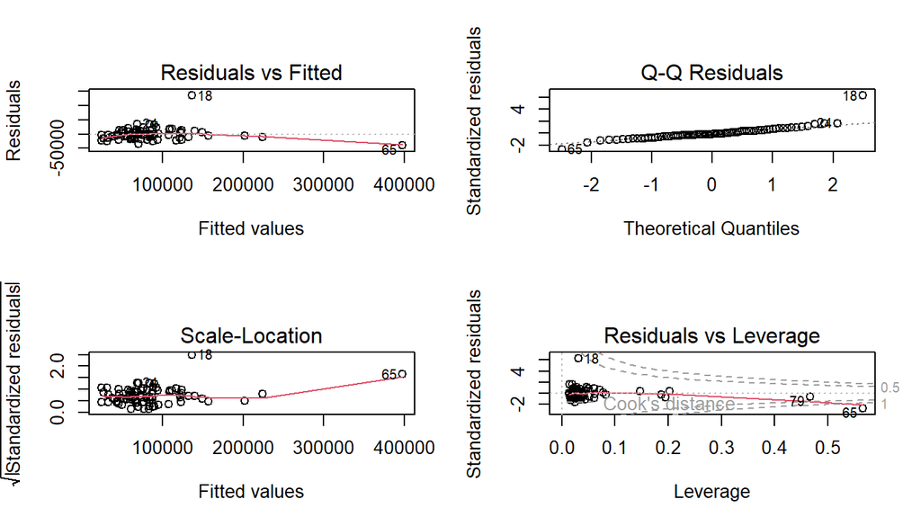

```r
par(mfrow = c(2, 2))
plot(mLm2019)
```

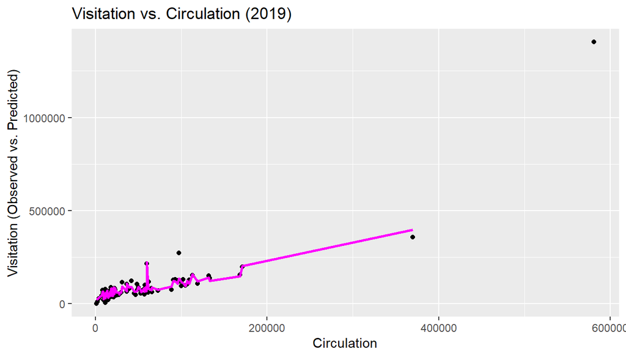

```r
par(mfrow = c(1, 1))

options(scipen = 999)

predicted2019 <- predict(mLm2019, newdata = aggregated_2019)

plotted2019Circ <- data.frame(Circulation = aggregated_2019$Circulation, Predicted_Visitation = predicted2019)
plotted2019Circ <- plotted2019Circ %>% arrange(Circulation)

ggplot(aggregated_2019, aes(x = Circulation, y = Visitation)) + geom_point() + geom_line(data = plotted2019Circ, aes(y = Predicted_Visitation), color = "magenta", linewidth = 1) + labs(title = "Visitation vs. Circulation (2019)", x = "Circulation", y = "Visitation (Observed vs. Predicted)")
```

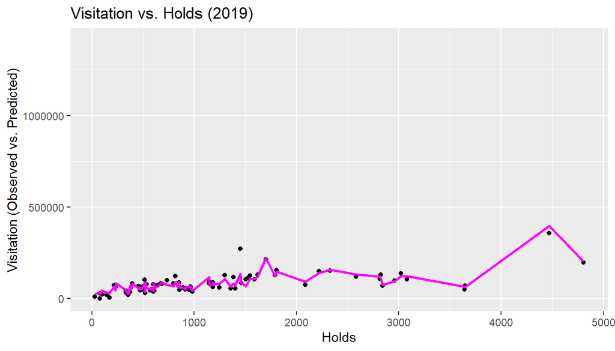

```r
plotted2019Holds <- data.frame(Holds = aggregated_2019$Holds, Predicted_Visitation = predicted2019)
plotted2019Holds <- plotted2019Holds %>% arrange(Holds)

ggplot(aggregated_2019, aes(x = Holds, y = Visitation)) + geom_point() + geom_line(data = plotted2019Holds, aes(y = Predicted_Visitation), color = "magenta", linewidth = 1) + labs(title = "Visitation vs. Holds (2019)", x = "Holds", y = "Visitation (Observed vs. Predicted)")
```

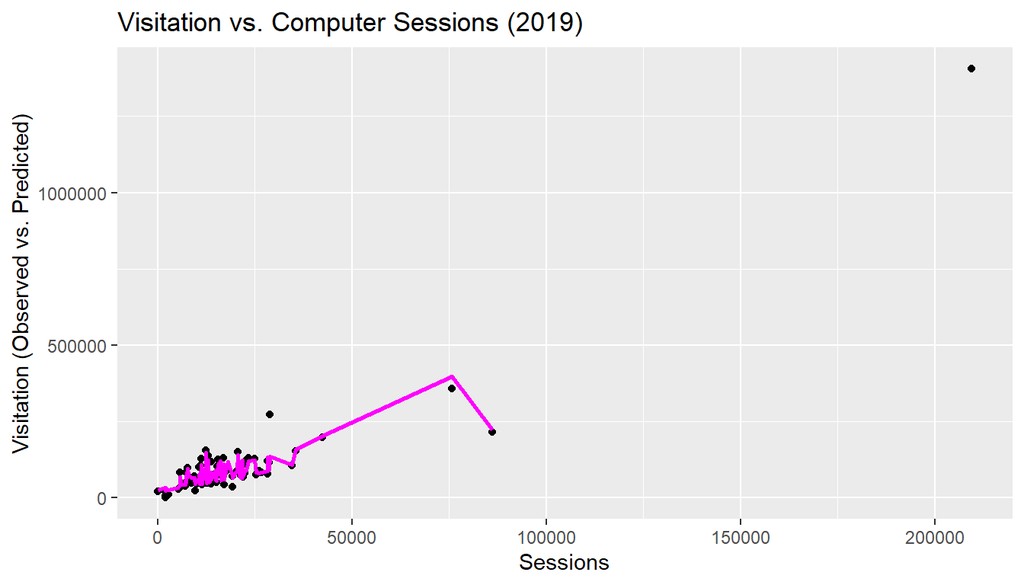

```r
plotted2019Sess <- data.frame(Sessions = aggregated_2019$Sessions, Predicted_Visitation = predicted2019)
plotted2019Sess <- plotted2019Sess %>% arrange(Sessions)

ggplot(aggregated_2019, aes(x = Sessions, y = Visitation)) + geom_point() + geom_line(data = plotted2019Sess, aes(y = Predicted_Visitation), color = "magenta", linewidth = 1) + labs(title = "Visitation vs. Computer Sessions (2019)", x = "Sessions", y = "Visitation (Observed vs. Predicted)")
```

##### IV.II.II. 2021

```r
summary(mLm2021)
```

```
##
## Call:
## lm(formula = Visitation ~ Circulation + Holds + Sessions, data = aggregated_2021)
##
## Residuals:
##    Min     1Q Median     3Q    Max
## -21013  -7689  -1058   5978  40375
##
## Coefficients:
##               Estimate Std. Error t value            Pr(>|t|)
## (Intercept) 5637.32338 2498.98885   2.256              0.0271 *
## Circulation    0.48634    0.04942   9.842 0.00000000000000501 ***
## Holds          2.11269    2.75021   0.768              0.4449
## Sessions       1.70399    0.31946   5.334 0.00000103255419934 ***
## ---
## Signif. codes:  0 '***' 0.001 '**' 0.01 '*' 0.05 '.' 0.1 ' ' 1
##
## Residual standard error: 10840 on 73 degrees of freedom
##   (3 observations deleted due to missingness)
## Multiple R-squared:  0.8671, Adjusted R-squared:  0.8617
## F-statistic: 158.8 on 3 and 73 DF,  p-value: < 0.00000000000000022
```

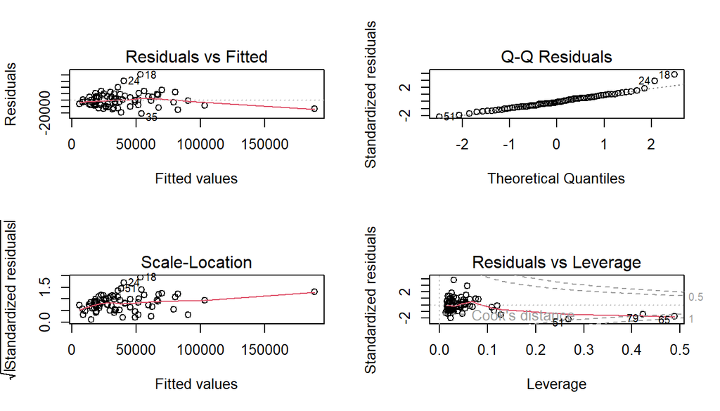

```r
par(mfrow = c(2, 2))
plot(mLm2021)
```

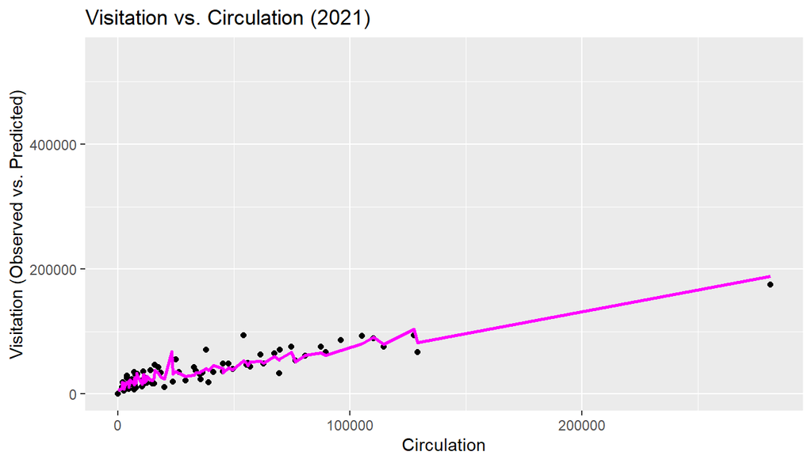

```r
par(mfrow = c(1, 1))

options(scipen = 999)

predicted2021 <- predict(mLm2021, newdata = aggregated_2021)

plotted2021Circ <- data.frame(Circulation = aggregated_2021$Circulation, Predicted_Visitation = predicted2021)
plotted2021Circ <- plotted2021Circ %>% arrange(Circulation)

ggplot(aggregated_2021, aes(x = Circulation, y = Visitation)) + geom_point() + geom_line(data = plotted2021Circ, aes(y = Predicted_Visitation), color = "magenta", linewidth = 1) + labs(title = "Visitation vs. Circulation (2021)", x = "Circulation", y = "Visitation (Observed vs. Predicted)")
```

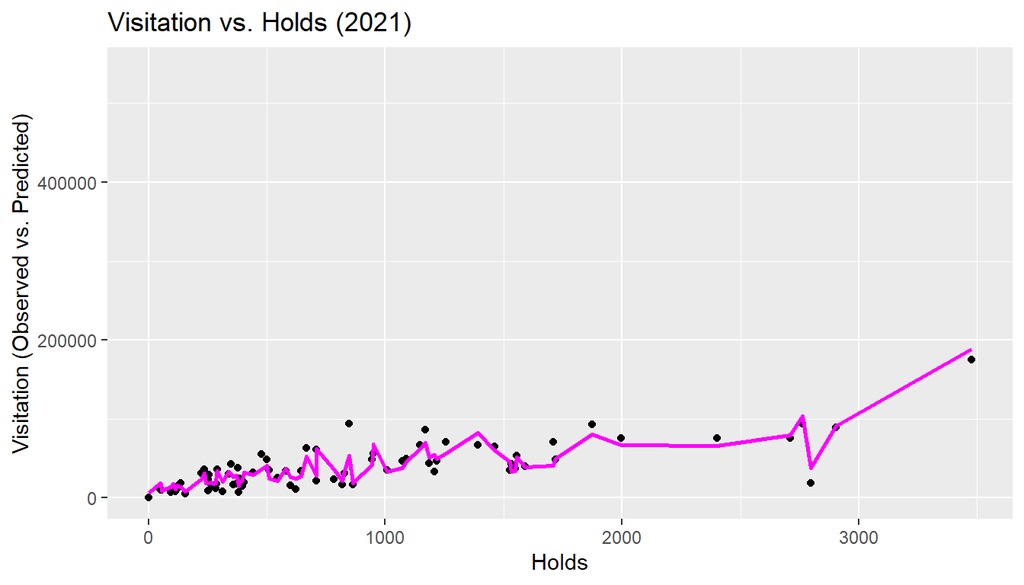

```r
plotted2021Holds <- data.frame(Holds = aggregated_2021$Holds, Predicted_Visitation = predicted2021)
plotted2021Holds <- plotted2021Holds %>% arrange(Holds)

ggplot(aggregated_2021, aes(x = Holds, y = Visitation)) + geom_point() + geom_line(data = plotted2021Holds, aes(y = Predicted_Visitation), color = "magenta", linewidth = 1) + labs(title = "Visitation vs. Holds (2021)", x = "Holds", y = "Visitation (Observed vs. Predicted)")
```

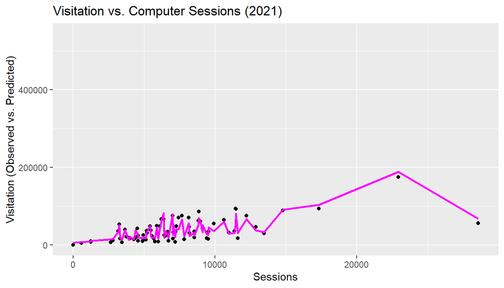

```r
plotted2021Sess <- data.frame(Sessions = aggregated_2021$Sessions, Predicted_Visitation = predicted2021)
plotted2021Sess <- plotted2021Sess %>% arrange(Sessions)

ggplot(aggregated_2021, aes(x = Sessions, y = Visitation)) + geom_point() + geom_line(data = plotted2021Sess, aes(y = Predicted_Visitation), color = "magenta", linewidth = 1) + labs(title = "Visitation vs. Computer Sessions (2021)", x = "Sessions", y = "Visitation (Observed vs. Predicted)")
```